# Boleta

**Objetivo de la práctica**

- Crear una app de escritorio/web con Flet que:
- Permita seleccionar un alumno y sus calificaciones por materia.
- Calcule el promedio.
- Agregue un registro a una tabla (DataTable).

**Requisitos previos**

- - Python 3.10+ instalado.
- - Editor recomendado: VS Code.
- - Conexión a internet para instalar dependencias.
1. Preparar el entorno

a) Crear carpeta del proyecto

Crea una carpeta, por ejemplo: boleta_flet

b) Crear y activar un entorno virtual

Windows (PowerShell):

```python
cd boleta_flet
py -m venv .venv
.\.venv\Scripts\Activate
```

c) Instalar Flet

```python
pip install flet
```

2. Crear el archivo base y probar “Hola Flet”

a) Crea el archivo main.py

b) Escribe y ejecuta este código mínimo:

```python
import flet as ft

def main(page: ft.Page):
    page.title = "Mi primera app con Flet"
    page.add(ft.Text("Hola Flet 👋"))

ft.app(target=main, view=ft.WEB_BROWSER)
```

3. Estructura general de la app (5 min)

Vamos a configurar la página (título, color de fondo y tamaño de ventana) y preparar los widgets (Dropdowns, Texto, Botón y Tabla).

Importante: en Flet, cada cambio visual requiere page.update() para reflejarse en la interfaz.

4. Construir los controles 4.1 Página y estilo básico

Reemplaza el contenido de main.py por este esqueleto y ejecútalo al final del punto 4:

```python
import flet as ft

def main(page: ft.Page):
    page.title = "Boleta de calificaciones"
    page.bgcolor = "purple"         # Fondo morado
    page.window_width = 1600
    page.window_height = 600
```

4.2 Dropdown de alumnos

```python
    lista_alumnos = ft.Dropdown(
        width=300,
        label="Alumnos",
        options=[
            ft.dropdown.Option("Juan Manuel Martínez"),
            ft.dropdown.Option("María Fernanda Pérez"),
            ft.dropdown.Option("José Luis González"),
            ft.dropdown.Option("Ana María Sánchez"),
            ft.dropdown.Option("Pedro Pérez Pérez"),
        ],
    )
```

4.3 Dropdowns de materias (valores 10–100 cada 10 puntos)

```python
    esp = ft.Dropdown(width=200, label="Español",
                      options=[ft.dropdown.Option(str(i)) for i in range(10, 101, 10)])
    mat = ft.Dropdown(width=200, label="Matemáticas",
                      options=[ft.dropdown.Option(str(i)) for i in range(10, 101, 10)])
    ing = ft.Dropdown(width=200, label="Inglés",
                      options=[ft.dropdown.Option(str(i)) for i in range(10, 101, 10)])
    info = ft.Dropdown(width=300, label="Informática",
                       options=[ft.dropdown.Option(str(i)) for i in range(10, 101, 10)])
    hist = ft.Dropdown(width=200, label="Historia",
                       options=[ft.dropdown.Option(str(i)) for i in range(10, 101, 10)])
```

4.4 Texto para mostrar el promedio

```python
    label_promedio = ft.Text(value="", size=20, width=100, color="white")
```

4.5 Tabla (DataTable) con columnas

```python
    tabla_calificaciones = ft.DataTable(
        columns=[
            ft.DataColumn(label=ft.Text("Alumno")),
            ft.DataColumn(label=ft.Text("Español")),
            ft.DataColumn(label=ft.Text("Matemáticas")),
            ft.DataColumn(label=ft.Text("Inglés")),
            ft.DataColumn(label=ft.Text("Informática")),
            ft.DataColumn(label=ft.Text("Historia")),
            ft.DataColumn(label=ft.Text("Promedio")),
        ],
        rows=[]
    )
```

4.6 Lógica: calcular promedio y agregar fila

- Tomamos los valores de cada dropdown.
- Calculamos el promedio.
- Mostramos el resultado y agregamos una nueva fila a la tabla.

```python
    def calcular_promedio(e):
        notas = [
            int(esp.value or 0),
            int(mat.value or 0),
            int(ing.value or 0),
            int(info.value or 0),
            int(hist.value or 0)
        ]
        promedio = sum(notas) / len(notas)
        label_promedio.value = f"{promedio:.2f}"

        nueva_fila = ft.DataRow(cells=[
            ft.DataCell(ft.Text(lista_alumnos.value or "")),
            ft.DataCell(ft.Text(esp.value or "")),
            ft.DataCell(ft.Text(mat.value or "")),
            ft.DataCell(ft.Text(ing.value or "")),
            ft.DataCell(ft.Text(info.value or "")),
            ft.DataCell(ft.Text(hist.value or "")),
            ft.DataCell(ft.Text(f"{promedio:.2f}")),
        ])
        tabla_calificaciones.rows.append(nueva_fila)
        page.update()
```

4.7 Botón para ejecutar la función

```python
    boton_calcular = ft.ElevatedButton(text="Calcular Promedio", on_click=calcular_promedio)
```

4.8 Organizar la interfaz (filas y columnas)

```python
    fila_dropdowns = ft.Row(
        [
            lista_alumnos,
            esp, mat, ing, info, hist,
            label_promedio
        ],
        alignment=ft.MainAxisAlignment.SPACE_AROUND
    )

    fila_boton = ft.Row(
        [boton_calcular],
        alignment=ft.MainAxisAlignment.CENTER
    )

    page.add(
        ft.Column(
            [
                fila_dropdowns,
                fila_boton,
                tabla_calificaciones
            ],
            alignment=ft.MainAxisAlignment.CENTER,
            spacing=20
        )
    )

ft.app(target=main, view=ft.WEB_BROWSER)
```

5. ¿Qué aprendieron en este ejercicio?
- Controles de entrada: Dropdown con label, width y options.
- Eventos: on_click (botón) y función que se dispara con el evento.
- Estado y render: Cambios en valores (por ejemplo, label_promedio.value) y page.update() para refrescar la UI.
- Componentes de tabla: DataTable → DataColumn + DataRow + DataCell.
6. Buenas prácticas y validaciones mínimas

Para clase, vale la pena evitar filas vacías o promedios con ceros si faltó seleccionar algo. Puedes mostrar un SnackBar si faltan datos:

```python
    def calcular_promedio(e):
        if not lista_alumnos.value or not all([esp.value, mat.value, ing.value, info.value, hist.value]):
            page.snack_bar = ft.SnackBar(ft.Text("Completa alumno y todas las materias."), open=True)
            page.update()
            return
        # ... resto igual ...
```

** Código Final **

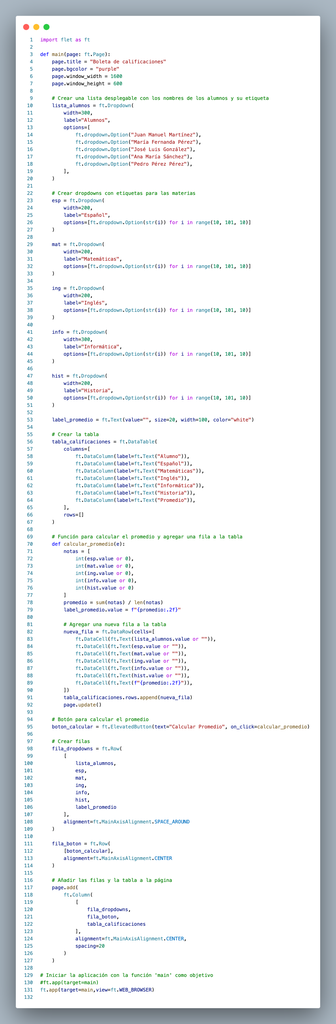